# Admission and Discharge of Drug Abuse and Mental Health Treatment Facilities

Amelia O’Leary

## File Downloads

If you are interested in downloading the files onto your local device, please follow the following links:

Markdown File: https://github.com/amoleary1763/amoleary1763.github.io/blob/master/MSDS692_DrugDischarge.Rmd HTML: https://github.com/amoleary1763/amoleary1763.github.io/blob/master/MSDS692_DrugDischarge.html

## Introduction

Addiction, drug use, and overdoses are not only a growing public health concern in America, but a largely preventable one. According to the Center for Disease Control and Prevention (CDC) 70,237 deaths occurred in the United States due to drug overdose. Additionally, the National Survey on Drug Use and Health reports 19.7 million people (ages 12 and older) struggled with a substance abuse disorder in that same year.

Psychological findings, legislation, and societal views are leading contributors to the rehabilitation programs that are available to people who battle this disease. In 1994, Switzerland passed progressive legislation which shifted focus from fighting against drugs to more available treatment options. This shift resulted in a 64% decrease in drug overdoses, as well as fewer cases in HIV and Hepatitis C infections, and a decrease in crime rates. Controversially, America is still fighting “The War on Drugs”. Drug abuse and addiction costs American’s over $740 billion annually with costs such as lost workplace productivity, healthcare expenses, and crime-related costs.

For this project I was interested in predicting the outcomes of the people who enroll in rehabilitation programs. I focused on two main questions:

1. How long will a patient be enrolled in a treatment program?
2. Will their discharge be successful?

By being able to predict the length of stay of a patient, facilities will better understand the type of treatment needed. Inpatient care tends to be a week to 30 days while outpatient care is usually greater than 90 days. By knowing this type of care, facilities can also estimate the cost of treatment which would directly benefit negotiation of grant funding, knowing insurance coverage, and understanding out of pocket expectations from the patient.

Understanding if a discharge is successful or not can help facilities employ intervention programs and additional or customizable treatment to ensure a successful/effective treatment and discharge. This also has the potential to reduce the need for several rehabilitation treatments of a patient, which would in turn reduce the costs and resources needed.

## Background and Data

The data used in the following analysis will be national data regarding discharges from state-funded substance abuse facilities for the year of 2017. The specific data set that will be utilized will be the *Treatment Episode Data Set Discharge*, also referred to as TEDS-D-2017 which can be found at the following link:

https://datafiles.samhsa.gov/study/treatment-episode-data-set-discharges-teds-d-2017-nid18479

Which contains 1,661,207 observations (unique case numbers) and 76 columns. This data contains information on the demographic and substance characteristics of treatment discharges and their corresponding admissions.

For the machine learning portion of this analysis we will be using two main target variables: LOS and REASON.

**LOS**: Describes the length of treatment. The variable is a combination of numeric and categorical values, where 1-30 indicate a single number of days while 31-37 are categorical values that indicate a range of days.

**REASON**: Indicates the outcome of treatment or other reason for transfer for discontinuance of treatment. This variable contains 7 categorical levels.

The data was curated and made available by The Substance Abuse and Mental Health Data Archive (SAMHDA), which collects, analyzes, and disseminates behavioral health data. This organization is an extension of the Center for Behavioral Health Statistics and Quality (CBHSQ) which provides these public-use data files and documentation in order to better understand this critical area of public health.

This data does include limitations, such as only including admissions to facilities that are licensed to certified by a state substance abuse agency to provide treatment and that receive state alcohol/drug agency funds for treatment. This varies state by state, meaning data sources could be biased based on state regulation and reporting. Records denote discharges, rather than individuals, and a person may be admitted and discharged more than once. This data also includes supplementary or calculated fields. A detailed codebook can be found at the following link:

http://samhda.s3-us-gov-west-1.amazonaws.com/s3fs-public/field-uploads-protected/studies/TEDS-D-2017/TEDS-D-2017-datasets/TEDS-D-2017-DS0001/TEDS-D-2017-DS0001-info/TEDS-D-2017-DS0001-info-codebook.pdf

## Exploratory Analysis and Feature Engineering

In this exploratory analysis I will look at frequency of drug type use, drug coincidence, number of drugs used, and descriptive statistics of target variables. General variable exploration was completed by going through the code book which outlines each variable with their definition (including categorical levels), variable type, frequency, and relative frequency. To reduce the processing expense for this analysis, I have manually reduced the columns.

### Drug Frequency

```r
# Setting up environment
knitr::opts_chunk$set(echo = TRUE, fig.width = 8.5, fig.height = 5, fig.align = "center")

library(dplyr)
library(reshape2)
library(ggplot2)
library(ggpubr)
library(rpart)
library(rattle)
library(randomForest)
options(scipen = 999, warn = -1)

load("C:/Users/Amelia/Documents/Graduate/MSDS 692/TEDS-D-2017-DS0001-bndl-data-r/tedsd_puf_2017.RData")
```

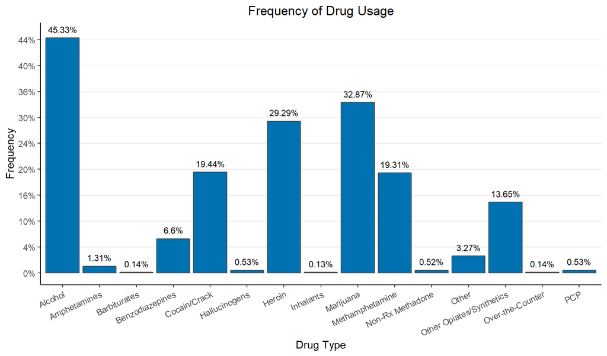

```r
# Reduced Data Set (76 to 47 columns)

dat <- tedsd_puf_2017 %>%
  select("AGE", "ALCDRUG", "ALCFLG", "AMPHFLG", "ARRESTS", "BARBFLG", "BENZFLG", "CBSA2010",
         "COKEFLG", "DSMCRIT", "EDUC", "EMPLOY", "ETHNIC", "FREQ1", "FREQ2", "FREQ3",
         "FREQ_ATND_SELF_HELP", "FRSTUSE1", "FRSTUSE2", "FRSTUSE3", "GENDER", "HALLFLG",
         "HERFLG", "HLTHINS", "HERFLG", "IDU", "INHFLG", "LIVARAG", "LOS", "MARFLG", "MARSTAT",
         "METHFLG", "METHUSE", "MTHAMFLG", "NOPRIOR", "OPSYNFLG", "OTCFLG", "OTHERFLG",
         "PCPFLG", "PREG", "PRIMINC", "PSYPROB", "RACE", "REASON", "SUB1", "SUB2", "SUB3", "VET")

# Frequency of Drug Flags

drugs <- list("Alcohol", "Amphetamines", "Barbiturates", "Benzodiazepines", "Cocain/Crack",
           "Hallucinogens", "Heroin", "Inhalants", "Marijuana", "Non-Rx Methadone",
           "Methamphetamine", "Other Opiates/Synthetics", "Over-the-Counter", "Other", "PCP")

flgs <- dat[, grep("FLG", colnames(dat))]
flgs_melt <- melt(flgs) %>%
  filter(value == 1) %>%
  group_by(variable) %>%
  count() %>%
  ungroup() %>%
  mutate(drug_type = as.character(drugs)) %>%
  mutate(pct = round(n/nrow(dat), 4))

ggplot(flgs_melt, aes(drug_type, pct)) +
  geom_bar(stat = "identity", fill = "#0072B2", color = "gray30") +
  geom_text(label = paste0(flgs_melt$pct * 100, "%"), vjust = -.8, size = 3) +
  scale_y_continuous(labels = scales::percent_format(2), limits = c(0,.46), breaks = seq(0, .45, by = .05))  +
  labs(title = "Frequency of Drug Usage", y = "Frequency", x = "Drug Type") +
  theme_classic() +
  theme(plot.title = element_text(hjust = .5),
        axis.text.x = element_text(angle = 25, hjust = 1, vjust = 1),
        panel.grid.major.x = element_blank(),
        panel.grid.major.y = element_line(size = .1, color = "#dbdbdb"))
```

### Drug Coincidence

Since we have a large amount of mixed numeric and categorical variables, instead of doing a typical correlation matrix I would like to look a the coincidence. This means “Out of all the people who reported alcohol, what is the next highest co-occurring drug?”. Looking at the frequency graph above, I am going to explore the coincidence of the top three most used drugs: Alcohol, Heroin, Marijuana.

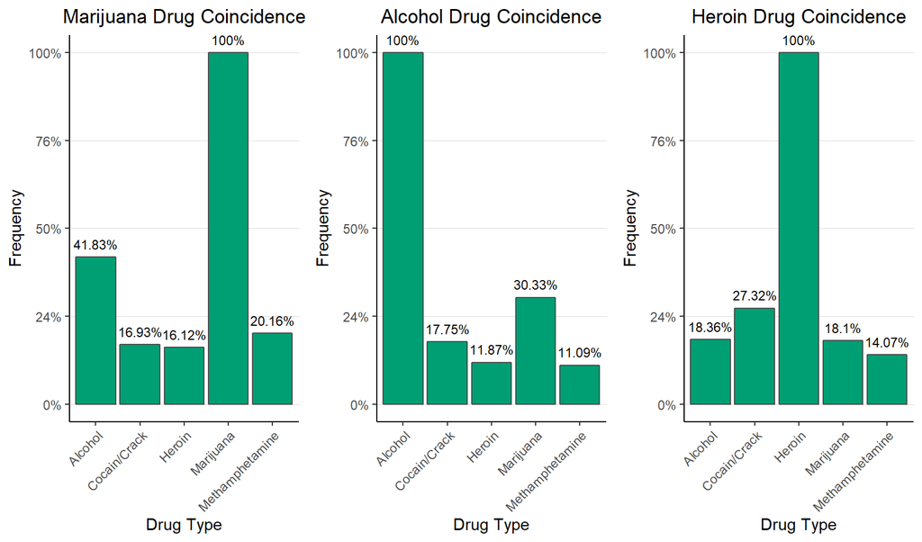

```r
flgs <- flgs[, c(1:15)]

coinciDANCE <- function(x) {

  z <- enquo(x)

  cnt <- flgs %>%
    filter(!!z == 1)

  y <- cnt %>%
    melt() %>%
    filter(value == 1) %>%
    group_by(variable) %>%
    count() %>%
    ungroup() %>%
    mutate(drug_type = as.character(drugs)) %>%
    mutate(pct = round(n/nrow(cnt), 4))

  top <- top_n(n = 5, x = y, wt = pct)

  return(top)

}

flgs_mar <- coinciDANCE(MARFLG)
flgs_alc <- coinciDANCE(ALCFLG)
flgs_her <- coinciDANCE(HERFLG)

plotme <- function(x, y) {

  ggplot(x, aes(drug_type, pct)) +
    geom_bar(stat = "identity", fill = "#009E73", color = "gray30") +
    geom_text(label = paste0(x$pct * 100, "%"), vjust = -.8, size = 3) +
    scale_y_continuous(labels = scales::percent_format(2))  +
    labs(title = paste(y, "Drug Coincidence"), y = "Frequency", x = "Drug Type") +
    theme_classic() +
    theme(axis.text.x = element_text(angle = 45, hjust = 1, vjust = 1),
          plot.title = element_text(hjust = .5),
          panel.grid.major.x = element_blank(),
          panel.grid.major.y = element_line(size = .1, color = "#dbdbdb"))

}

plot_mar <- plotme(flgs_mar, "Marijuana")
plot_alc <- plotme(flgs_alc, "Alcohol")
plot_her <- plotme(flgs_her, "Heroin")

ggarrange(plot_mar, plot_alc, plot_her,
          ncol = 3, nrow = 1)
```

From these graphs, we can see that Alcohol and Marijuana are the most prominent drug use co-occurrence, followed by Heroin and Cocaine/Crack. In other words, we can see that those who use Alcohol are more likely to also use Marijuana, those who use Marijuana are more likely to also use Alcohol, and those who use Heroin are more likely to use Cocaine/Crack.

### Frequency of Drug Coincidence

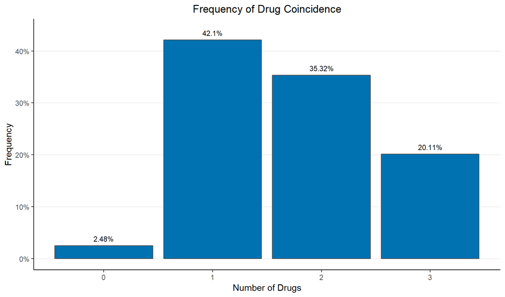

```r
flgs$TOT_DRUGS <- raster::rowSums(flgs)
flgs_freq <- flgs %>%
  group_by(TOT_DRUGS) %>%
  count() %>%
  ungroup() %>%
  mutate(pct = round(n/nrow(dat), 4))

ggplot(flgs_freq, aes(TOT_DRUGS, pct)) +
  geom_bar(stat = "identity", fill = "#0072B2", color = "gray30") +
  geom_text(label = paste0(flgs_freq$pct * 100, "%"), vjust = -.8, size = 3) +
  scale_y_continuous(labels = scales::percent_format(2), limits = c(0,.44), breaks = seq(0, .40, by = .1))  +
  labs(title = "Frequency of Drug Coincidence", y = "Frequency", x = "Number of Drugs") +
  theme_classic() +
  theme(plot.title = element_text(hjust = .5),
        panel.grid.major.x = element_blank(),
        panel.grid.major.y = element_line(size = .1, color = "#dbdbdb"))
```

Most people report having more than one drug usage when admitting into rehabilitation (55.43%). Understanding the drug frequency and coincidence can help facilities orient the patient with the best treatments, understand withdrawal symptoms, and provide the most effective support to patients during rehabilitation.

### Target Variables

#### LOS

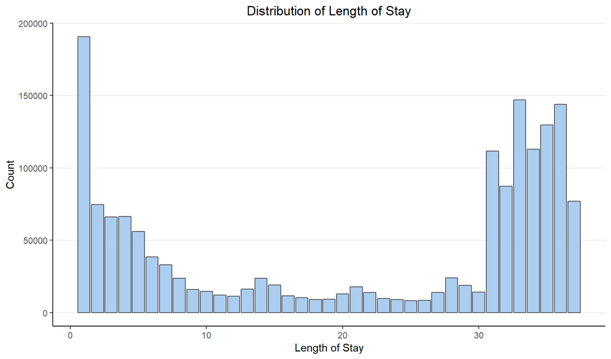

```r
los <- tedsd_puf_2017 %>%
  group_by(LOS) %>%
  count()

ggplot(los, aes(LOS, n)) +
  geom_bar(stat = "identity", fill = "#ABCDEF", color = "gray30") +
  labs(title = "Distribution of Length of Stay", x = "Length of Stay", y = "Count") +
  theme_classic() +
  theme(plot.title = element_text(hjust = .5),
        panel.grid.major.y = element_line(size = .1, color = "#dbdbdb"))
```

I find this distribution pretty interesting. We can see a small inflation around 14, 21, and 28 days, which most likely indicates standard treatment lengths within rehabilitation programs.

Since Length of stay is both numeric and categorical (1-30 vs 31-37, respectively), I will evaluate each section separately.

```r
summary(tedsd_puf_2017 %>% filter(LOS < 31) %>% select(LOS))
```

```
##       LOS
##  Min.   : 1.000
##  1st Qu.: 2.000
##  Median : 5.000
##  Mean   : 8.942
##  3rd Qu.:14.000
##  Max.   :30.000
```

Looking at the numeric values of days 1-30, we can see the average stay is about 9 days with a median of 5 days. This indicates that either patients are receiving short term rehabilitation programs or are not completing their program.

```r
summary(tedsd_puf_2017 %>% filter(LOS > 30) %>% select(LOS) %>% mutate(LOS = as.factor(LOS)))
```

```
##  LOS
##  31:111509
##  32: 87167
##  33:146958
##  34:112776
##  35:129821
##  36:143977
##  37: 77053
```

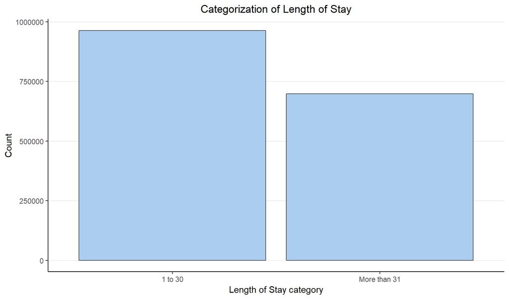

```r
dat <- dat %>%
  mutate(LOS_cat = ifelse(dat$LOS <= 31, "1 to 30",
                          ifelse(dat$LOS >= 31, "More than 31", "NA")))

dat$LOS_cat <- factor(dat$LOS_cat, levels = c("1 to 30", "More than 31"))

los <- dat %>%
  group_by(LOS_cat) %>%
  count()

ggplot(los, aes(LOS_cat, n)) +
  geom_bar(stat = "identity", fill = "#ABCDEF", color = "gray30") +
  labs(title = "Categorization of Length of Stay", x = "Length of Stay category", y = "Count") +
  theme_classic() +
  theme(plot.title = element_text(hjust = .5),
        panel.grid.major.y = element_line(size = .1, color = "#dbdbdb"))
```

This distribution is pretty good. We don’t see one categorization have a significantly more amount of observations than the other, making it reliable for a machine learning algorithm to categorize. Additionally, we can see that every observation has a categorization, ensuring that we are not introducing any NA values.

#### REASON

Reason is a categorical variable that indicates the reason for the discontinuance of treatment.

| Value | Description | Frequency | Percent |
| --- | --- | --- | --- |
| 1 | Treatment completed | 679,850 | 40.9% |
| 2 | Dropped out of treatment | 425,444 | 25.6% |
| 3 | Terminated by facility | 99,319 | 6.0% |
| 4 | Transferred to another treatment program or facility | 363,591 | 21.9% |
| 5 | Incarcerated | 29.650 | 1.8% |
| 6 | Death | 3,788 | 0.2% |
| 7 | Other | 59,565 | 3.6% |

More specific definitions of the descriptions are as follows:

- Treatment completed: All parts of the treatment plan or program were completed.
- Dropped out of treatment (left against professional advice): Client chose not to complete program, with or without specific advice to continue treatment. Includes clients who drop out of treatment for unknown reason and clients who have not received treatment for some time and are discharged for administrative reasons.
- Terminated by facility: Treatment terminated by action of facility, generally because of client non-compliance or violation of rules, laws, or procedures (not because client dropped out of treatment, client incarcerated, or other client motivated reason).
- Transferred to another substance use treatment program or facility: Client was transferred to another substance use treatment program, provider or facility within an episode of treatment.
- Incarcerated: This code is to be used for all clients whose course of treatment is terminated because the client has been incarcerated. Includes jail, prison, and house confinement.
- Death
- Other: Moved, illness, hospitalization, or other reason somewhat out of client’s control.

For this variable, I am going to create a new data set that only includes patients that have *Treatment completed* (1), *Dropped out of treatment* (2), and *Terminated by facility* (3). These will then be categorized into two groups, “Successful” and “Unsuccessful”, where values 1 will be successful and values 2 and 3 will be unsuccessful.

[figure not shown]

```r
dat_reason <- dat %>%
  mutate(REASON_cat = ifelse(dat$REASON == 1, "Successful",
                             ifelse(dat$REASON == 2, "Unsuccessful",
                                    ifelse(dat$REASON == 3, "Unsuccessful", NA)))) %>%
  filter(!is.na(REASON_cat))

reason <- dat_reason %>%
  group_by(REASON_cat) %>%
  count()

ggplot(reason, aes(REASON_cat, n)) +
  geom_bar(stat = "identity", fill = "#ABCDEF", color = "gray30") +
  labs(title = "Categorization of Length of Stay", x = "Length of Stay Category", y = "Count") +
  theme_classic() +
  theme(plot.title = element_text(hjust = .5),
        panel.grid.major.y = element_line(size = .1, color = "#dbdbdb"))
```

Once again, our distribution looks fine. Successful discharges have a slightly higher frequency than unsuccessful dischargers (This is great!), but shouldn’t be a problem when running machine learning algorithms.

Now that we understand our data and have clean, usable data, we can move to machine learning algorithms.

## Machine Learning

### Creating Samples

We will need to create two samples, since we have two different target variables. Since the dataset is so large, we will be taking a random sample of 60,000 observations. The sample will then be split into a training and test set, at a 75% and 25% split, respectively.

```r
set.seed(123)

# Sample for LOS
dat.sample.los <- sample_n(dat, 60000)

# Removing LOS variable
dat.sample.los <- dat.sample.los[-28]

samp.los <- sample(nrow(dat.sample.los),0.75* nrow(dat.sample.los))
train.los <- dat.sample.los[samp.los, ]
test.los <- dat.sample.los[-samp.los, ]

# Sample for REASON
dat.sample.reas <- sample_n(dat_reason, 60000)

# Removing LOS_cat and REASON variable
dat.sample.reas <- dat.sample.reas[, -c(43,48)]

samp.reas <- sample(nrow(dat.sample.reas),0.75* nrow(dat.sample.reas))
train.reas <- dat.sample.reas[samp.reas, ]
test.reas <- dat.sample.reas[-samp.reas, ]
```

### Decision Tree and Variable Selection

For the project I decided to use a decision tree for categorization, but also for variable selection. This data is largely categorical, and just plain large, which a decision tree will be able to handle. Additionally, this methodology will select contributing variables to classification.

### LOS

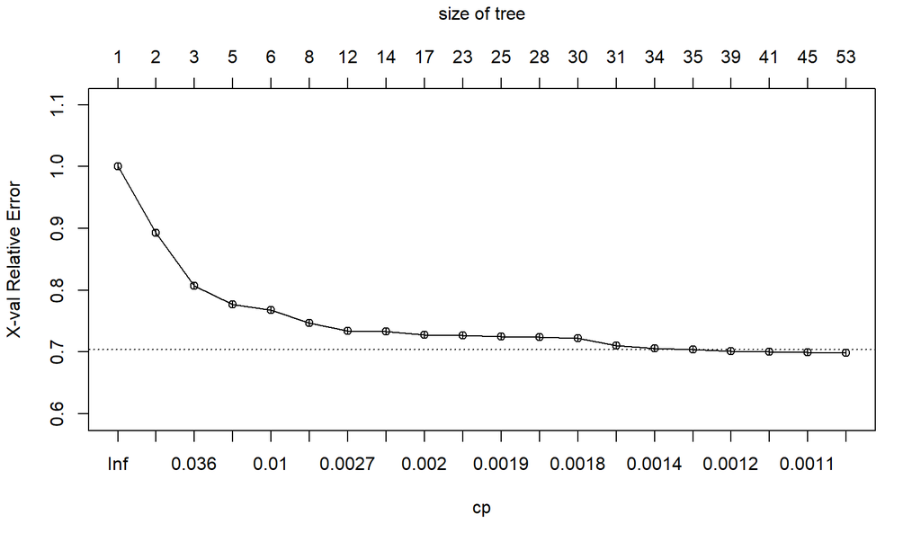

```r
DecisionTree <- rpart(LOS_cat ~ ., dat = train.los,
                      control=rpart.control(minsplit = 1, minbucket = 1, cp = 0.001))

plotcp(DecisionTree)
```

```r
printcp(DecisionTree)
```

```
##
## Classification tree:
## rpart(formula = LOS_cat ~ ., data = train.los, control = rpart.control(minsplit = 1,
##     minbucket = 1, cp = 0.001))
##
## Variables actually used in tree construction:
##  [1] AGE                 CBSA2010            DSMCRIT
##  [4] EMPLOY              FREQ_ATND_SELF_HELP FREQ1
##  [7] FREQ2               HLTHINS             IDU
## [10] LIVARAG             MARFLG              METHUSE
## [13] PRIMINC             PSYPROB             RACE
## [16] REASON              SUB1                SUB2
##
## Root node error: 18831/45000 = 0.41847
##
## n= 45000
##
##           CP nsplit rel error  xerror      xstd
## 1  0.1068451      0   1.00000 1.00000 0.0055571
## 2  0.0859753      1   0.89315 0.89315 0.0054500
## 3  0.0152143      2   0.80718 0.80718 0.0053278
## 4  0.0116298      4   0.77675 0.77675 0.0052765
## 5  0.0093994      5   0.76512 0.76799 0.0052608
## 6  0.0032261      7   0.74632 0.74717 0.0052222
## 7  0.0022038     11   0.73342 0.73459 0.0051979
## 8  0.0020002     13   0.72901 0.73283 0.0051944
## 9  0.0019648     16   0.72301 0.72800 0.0051848
## 10 0.0018852     22   0.70952 0.72705 0.0051829
## 11 0.0018763     24   0.70575 0.72503 0.0051788
## 12 0.0018321     27   0.70012 0.72407 0.0051769
## 13 0.0017524     29   0.69646 0.72259 0.0051739
## 14 0.0014338     30   0.69471 0.71074 0.0051495
## 15 0.0013276     33   0.69040 0.70586 0.0051393
## 16 0.0012745     34   0.68908 0.70426 0.0051359
## 17 0.0011417     38   0.68398 0.70156 0.0051301
## 18 0.0011019     40   0.68170 0.70055 0.0051280
## 19 0.0010090     44   0.67729 0.69938 0.0051254
## 20 0.0010000     52   0.66900 0.69879 0.0051242
```

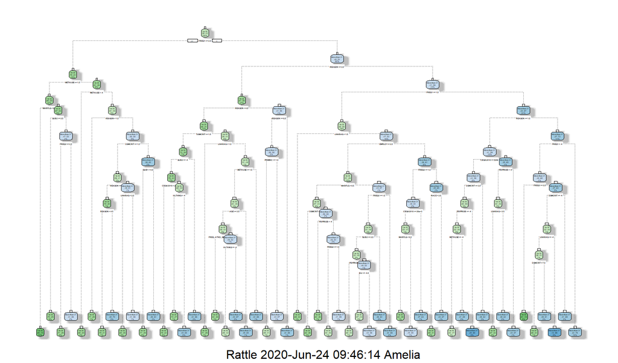

```r
fancyRpartPlot(DecisionTree)
```

```r
pred1 <- predict(DecisionTree, test.los, type = "class")
acc <- table(test.los$LOS_cat, pred1)
acc
```

```
##               pred1
##                1 to 30 More than 31
##   1 to 30         6724         2038
##   More than 31    2126         4112
```

```r
# Accuracy
sum(diag(acc)) / sum(acc)
```

```
## [1] 0.7224
```

```r
# Recall
acc[1,1]/(acc[1,1] + acc[1,2])
```

```
## [1] 0.7674047
```

```r
# Precision
acc[1,1]/(acc[1,1] + acc[2,1])
```

```
## [1] 0.759774
```

### REASON

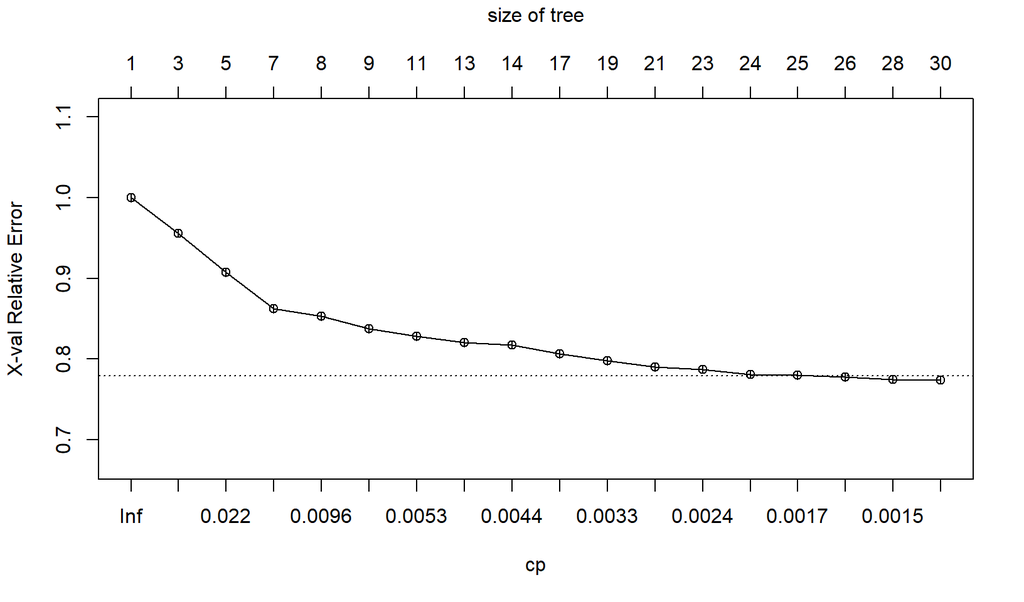

```r
DecisionTree <- rpart(REASON_cat ~ ., dat = train.reas,
                      control=rpart.control(minsplit = 1, minbucket = 1, cp = 0.0014))

plotcp(DecisionTree)
```

```r
printcp(DecisionTree)
```

```
##
## Classification tree:
## rpart(formula = REASON_cat ~ ., data = train.reas, control = rpart.control(minsplit = 1,
##     minbucket = 1, cp = 0.0014))
##
## Variables actually used in tree construction:
##  [1] ALCDRUG             ARRESTS             CBSA2010
##  [4] DSMCRIT             FREQ_ATND_SELF_HELP FREQ1
##  [7] FREQ2               HLTHINS             LOS
## [10] MARFLG              METHUSE             PRIMINC
## [13] PSYPROB             SUB1
##
## Root node error: 19656/45000 = 0.4368
##
## n= 45000
##
##           CP nsplit rel error  xerror      xstd
## 1  0.0300672      0   1.00000 1.00000 0.0053528
## 2  0.0232753      2   0.93987 0.95604 0.0053223
## 3  0.0199685      4   0.89332 0.90746 0.0052790
## 4  0.0098189      6   0.85338 0.86259 0.0052297
## 5  0.0094119      7   0.84356 0.85323 0.0052183
## 6  0.0061813      8   0.83415 0.83776 0.0051985
## 7  0.0046296     10   0.82178 0.82819 0.0051858
## 8  0.0044770     12   0.81253 0.82041 0.0051751
## 9  0.0042989     13   0.80805 0.81761 0.0051711
## 10 0.0035104     16   0.79441 0.80657 0.0051553
## 11 0.0031543     18   0.78739 0.79813 0.0051429
## 12 0.0024420     20   0.78108 0.79034 0.0051311
## 13 0.0023403     22   0.77620 0.78729 0.0051264
## 14 0.0018315     23   0.77386 0.78129 0.0051170
## 15 0.0016280     24   0.77203 0.78012 0.0051151
## 16 0.0015008     25   0.77040 0.77788 0.0051116
## 17 0.0014245     27   0.76740 0.77508 0.0051071
## 18 0.0014000     29   0.76455 0.77406 0.0051054
```

[figure not shown]

```r
fancyRpartPlot(DecisionTree)
```

```r
pred1 <- predict(DecisionTree, test.reas, type = "class")
acc <- table(test.los$LOS_cat, pred1)
acc
```

[output not shown]

```r
# Accuracy
sum(diag(acc)) / sum(acc)
```

```
## [1] 0.5297333
```

```r
# Recall
acc[1,1]/(acc[1,1] + acc[1,2])
```

```
## [1] 0.6832915
```

```r
# Precision
acc[1,1]/(acc[1,1] + acc[2,1])
```

```
## [1] 0.5831872
```

### Random Forest

```r
new.train.los <- train.los %>%
  select("CBSA2010", "DSMCRIT", "EMPLOY", "FREQ1", "FREQ2", "FREQ3",
         "LIVARAG", "MARFLG", "METHUSE", "MTHAMFLG", "PRIMINC", "PSYPROB",
         "REASON", "SUB1", "SUB2", "LOS_cat")

new.train.reas <- train.reas %>%
  select("ALCDRUG", "ARRESTS", "CBSA2010", "DSMCRIT",
         "FREQ_ATND_SELF_HELP", "FREQ1", "HLTHINS", "LOS",
         "MARFLG", "METHUSE", "PRIMINC", "PSYPROB", "SUB1", "SUB2", "REASON_cat")

new.test.los <- test.los %>%
  select("CBSA2010", "DSMCRIT", "EMPLOY", "FREQ1", "FREQ2", "FREQ3",
         "LIVARAG", "MARFLG", "METHUSE", "MTHAMFLG", "PRIMINC", "PSYPROB",
         "REASON", "SUB1", "SUB2", "LOS_cat")

new.test.reas <- test.reas %>%
  select("ALCDRUG", "ARRESTS", "CBSA2010", "DSMCRIT",
         "FREQ_ATND_SELF_HELP", "FREQ1", "HLTHINS", "LOS",
         "MARFLG", "METHUSE", "PRIMINC", "PSYPROB", "SUB1", "SUB2", "REASON_cat")
```

In the next section I will employ a random forest algorithm on both the custom LOS and REASON datasets. I chose a random forest for a lot of the same reasons from the decision tree, but random forests tend to run a little more accurate than decision trees. The hope is with the variable selection and more powerful algorithm, we will increase the accuracy, recall, and precision from the decision trees.

```r
# LOS

model <- randomForest(LOS_cat ~ ., dat = new.train.los)
model
```

```
##
## Call:
##  randomForest(formula = LOS_cat ~ ., data = new.train.los)
##                Type of random forest: classification
##                      Number of trees: 500
## No. of variables tried at each split: 3
##
##         OOB estimate of  error rate: 26.24%
## Confusion matrix:
##              1 to 30 More than 31 class.error
## 1 to 30        20788         5381    0.205625
## More than 31    6428        12403    0.341352
```

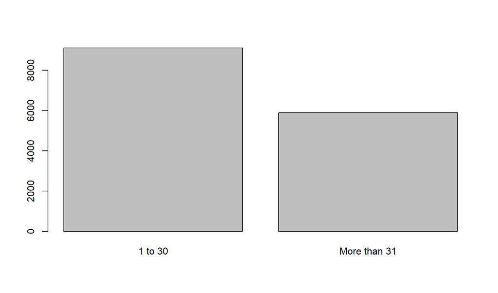

```r
pred2 <- predict(model, newdata = new.test.los)
plot(pred2)
```

```r
acc2 <- table(new.test.los$LOS_cat, pred2)
acc2
```

```
##               pred2
##                1 to 30 More than 31
##   1 to 30         6976         1786
##   More than 31    2134         4104
```

```r
# Accuracy
sum(diag(acc2)) / sum(acc2)
```

```
## [1] 0.7386667
```

```r
# Recall
acc2[1,1]/(acc2[1,1] + acc2[1,2])
```

```
## [1] 0.7961653
```

```r
# Precision
acc2[1,1]/(acc2[1,1] + acc2[2,1])
```

```
## [1] 0.7657519
```

```r
# REASON

new.train.reas$REASON_cat <- as.factor(new.train.reas$REASON_cat)

model2 <- randomForest(REASON_cat ~ ., dat = new.train.reas)
model2
```

```
##
## Call:
##  randomForest(formula = REASON_cat ~ ., data = new.train.reas)
##                Type of random forest: classification
##                      Number of trees: 500
## No. of variables tried at each split: 3
##
##         OOB estimate of  error rate: 28.19%
## Confusion matrix:
##              Successful Unsuccessful class.error
## Successful        20416         4928   0.1944444
## Unsuccessful       7758        11898   0.3946886
```

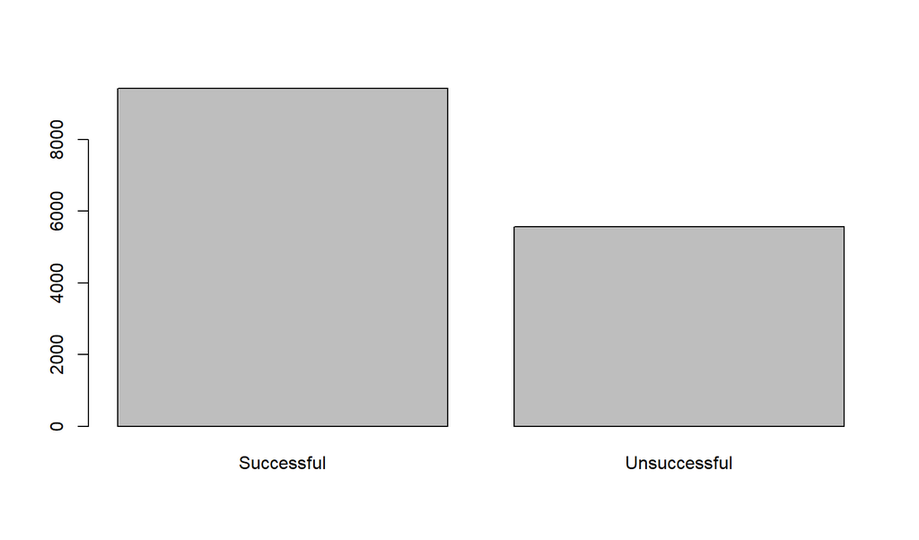

```r
pred3 <- predict(model2, newdata = new.test.reas)
plot(pred3)
```

```r
acc3 <- table(new.test.reas$REASON_cat, pred3)
acc3
```

```
##               pred3
##                Successful Unsuccessful
##   Successful         6873         1621
##   Unsuccessful       2557         3949
```

```r
# Accuracy
sum(diag(acc3)) / sum(acc3)
```

```
## [1] 0.7214667
```

```r
# Recall
acc3[1,1]/(acc3[1,1] + acc3[1,2])
```

```
## [1] 0.8091594
```

```r
# Precision
acc3[1,1]/(acc3[1,1] + acc3[2,1])
```

```
## [1] 0.7288441
```

## References

https://www.rehabs.com/drug-rehab-programs/

https://www.addictioncenter.com/treatment/inpatient-rehab/

https://www.cdc.gov/nchs/products/databriefs/db329.htm

https://americanaddictioncenters.org/rehab-guide/addiction-statistics

https://www.northcarolinahealthnews.org/2019/01/21/switzerland-couldnt-stop-drug-users-so-it-started-supporting-them/

https://towardsdatascience.com/beyond-accuracy-precision-and-recall-3da06bea9f6c